# Liberia Community-based Management of Acute Malnutrition Coverage Assessment

A report prepared for the Liberia Ministry of Health and UNICEF Liberia

MSc in International Health and Tropical Medicine Class 2023

University of Oxford

2023-03-17

## Introduction

A three-year nutrition programme has been implemented in Liberia by the Ministry of Health and UNICEF aimed at tackling child undernutrition in the country. Funded by [Power of Nutrition](http://www.powerofnutrition.org) and [UNICEF UK](https://www.unicef.org.uk), the programme has been implemented across 15 counties in Liberia starting from January 2017 up to December 2019. The overall aim of the programme is to improve the coverage of direct nutrition interventions or what is commonly termed nutrition-specific interventions, i.e. interventions or programmes that address the immediate determinants of foetal and child nutrition and development — adequate food and nutrient intake, feeding, caregiving and parenting practices, and low burden of infectious diseases. The current programme supports the following specific key interventions: 1) *treatment of severe acute malnutrition (SAM) within the community-based management of acute malnutrition (CMAM) programme for children 6-59 months*; 2) *vitamin A supplementation for children 6-59 months*; 3) *promotion of appropriate infant and young child feeding (IYCF) practices among pregnant or lactating women*; 4) *multiple micronutrient powder (MNP) supplementation for children 6-23 months*; and, 5) *iron and folic acid (IFA) supplementation for pregnant women*.

To assess the programme’s progress towards its overall aim, two coverage assessments have been implemented - the first at the halfway point of the programme and the second at the end. Only two programme areas were selected for the assessments: *Urban Montserrado (Greater Monrovia)* district and *Grand Bassa* county.

This document reports on the results of the coverage assessment of the CMAM programme for treating SAM children 6-59 months old.

## Description of the sample

### Children by sex and location

The following table presents the number of children in the sample by sex.

```r
sample_by_sex_table <- table(nut$sex, useNA = "ifany")

sample_by_sex_table
```

```
##
##    1    2 <NA>
## 6471 6239  101
```

There were a total of **6471 male children** and **6239 female children** in the survey sample. There were also a total of **101 children** whose parents refused to participate in the survey.

The following table presents the number of children in the sample by location.

```r
sample_by_location_table <- table(nut$county, useNA = "ifany")

sample_by_location_table
```

```
##
##       Grand Bassa Urban Montserrado
##              5355              7456
```

There were a total of **5355 children from Grand Bassa** and **7456 children from Urban Montserrado**.

The following table presents the number of children in the sample by sex and by location.

```r
sample_by_sex_location_table <- table(nut$county, nut$sex, useNA = "ifany")

sample_by_sex_location_table
```

```
##
##                        1    2 <NA>
##   Grand Bassa       2709 2615   31
##   Urban Montserrado 3762 3624   70
```

In Grand Bassa, there were a total of **2709 male children** and **2615 female children** in the survey sample. A total of **31 children** in Grand Bassa had parents who refused to participate in the survey.

In Urban Montserrado, there were a total of **3762 male children** and **3624 female children** in the survey sample. A total of **70 children** in Urban Montserrado had parents who refused to participate in the survey.

### Age distribution of children in the sample

Following is a barplot of ages of the children in the sample.

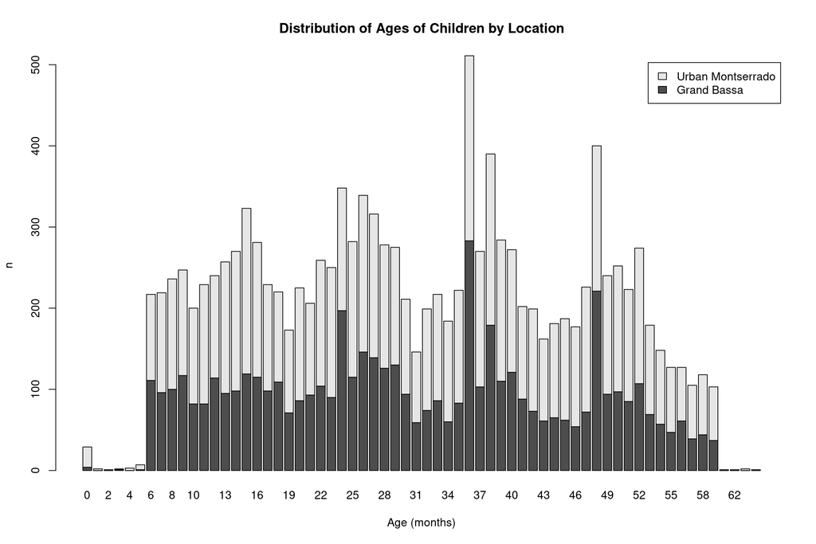

Distribution of ages of children by location

```r
barplot(
  height = table(nut$county, nut$age),
  beside = FALSE,
  legend.text = TRUE,
  main = "Distribution of Ages of Children by Location",
  xlab = "Age (months)",
  ylab = "n"
)
```

Following is a histogram of ages of children in the sample.

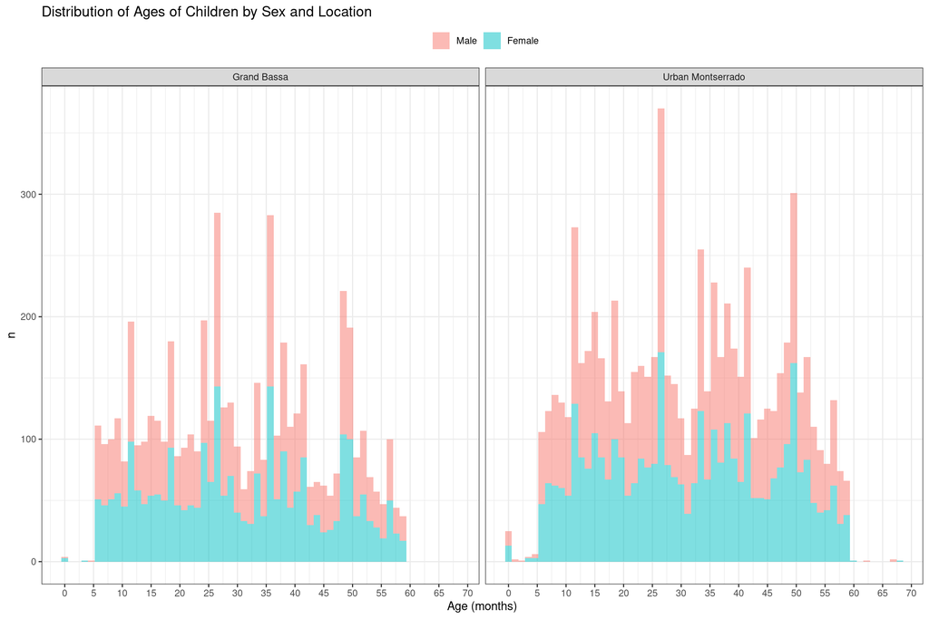

Distribution of ages of children

```r
ggplot(
  data = nut,
  aes(
    x = age,
    fill = factor(sex, labels = c("Male", "Female")),
    group = factor(sex, labels = c("Male", "Female"))
  )
) +
  geom_histogram(alpha = 0.5, bins = 60) +
  scale_x_continuous(n.breaks = 24) +
  facet_wrap( ~ county, ncol = 2) +
  labs(
    title = "Distribution of Ages of Children by Sex and Location",
    x = "Age (months)", y = "n",
    fill = NULL
  ) +
  theme_bw() +
  theme(legend.position = "top")
```

## Nutrition screening coverage

The following data processing was first performed on the data before continuing on with the analysis.

```r
## Subset data: Transform variables of interest into table nut1
nut1 <- nut %>% select(survey_round,county,sex,muac_screen,oedema_screen)

## Clean data in subset: Change 99 to NA
### Clean data only after having made subset nut1.
### Code don't work if data is cleaned in nut and then subset. ???
nut1$muac_screen <- ifelse(nut1$muac_screen == 99, NA, nut1$muac_screen)
nut1$muac_screen[nut$muac_screen == 1] <- "Y"
nut1$muac_screen[nut$muac_screen == 2] <- "N"

nut1$oedema_screen <- ifelse(nut1$oedema_screen == 99, NA, nut1$oedema_screen)
nut1$oedema_screen[nut$oedema_screen == 1] <- "Y"
nut1$oedema_screen[nut$oedema_screen == 2] <- "N"

nut1$sex <- ifelse(nut1$sex == 1, "Male", "Female")
```

### MUAC screening coverage

The following table presents MUAC screening coverage by survey round.

```r
nut1 %>%
  tbl_summary(
    by = survey_round,
    include = muac_screen,
    statistic = list(all_continuous() ~ "{mean} ({sd})")
  )
```

| **Characteristic** | **Baseline**, N = 6,289<sup>1</sup> | **Endline**, N = 6,522<sup>1</sup> |
| --- | --- | --- |
| muac_screen |  |  |
| N | 4,556 (96%) | 6,026 (96%) |
| Y | 208 (4.4%) | 230 (3.7%) |
| Unknown | 1,525 | 266 |

<sup>1</sup> n (%)

The endline data shows LITTLE if NO improvement in MUAC screening coverage among the sample children vs. baseline. Percentage of children had MUAC screened (answered 1 to survey) stayed relatively the same from baseline to endline. The percentage of children without MUAC screening went up from 73% to 93%, mainly due to children from the NA population at baseline moving over. This may suggest a better awareness in this population related to not having gotten MUAC screening (?).

The following table presents MUAC screening coverage by survey round and by sex of the child.

```r
nut1 %>%
  tbl_strata(
    strata = sex,
    .tbl_fun = ~ .x %>%
      tbl_summary(
        by = survey_round,
        include = muac_screen,
        statistic = list(all_continuous() ~ "{mean} ({sd})")
      )
  )
```

| **Characteristic** | **Female** **Baseline**, N = 3,048<sup>1</sup> | **Female** **Endline**, N = 3,191<sup>1</sup> | **Male** **Baseline**, N = 3,186<sup>1</sup> | **Male** **Endline**, N = 3,285<sup>1</sup> | **NA** **Baseline**, N = 55<sup>1</sup> | **NA** **Endline**, N = 46<sup>1</sup> |
| --- | --- | --- | --- | --- | --- | --- |
| muac_screen |  |  |  |  | 0 (NA%) | 0 (NA%) |
| N | 2,215 (96%) | 2,995 (97%) | 2,341 (95%) | 3,031 (96%) |  |  |
| Y | 86 (3.7%) | 102 (3.3%) | 122 (5.0%) | 128 (4.1%) |  |  |
| Unknown | 747 | 94 | 723 | 126 | 55 | 46 |

<sup>1</sup> n (%)

There is no apparent difference in MUAC screening coverage between girls and boys in the sample. Or, gender doesn’t seem to influence MUAC screening in children.

The following table presents MUAC screening coverage by survey round and by survey location.

```r
nut1 %>%
  tbl_strata(
    strata=county,
    .tbl_fun = ~ .x %>%
      tbl_summary(
        by = survey_round,
        include = muac_screen,
        statistic = list(all_continuous() ~ "{mean} ({sd})")
      )
   )
```

| **Characteristic** | **Grand Bassa** **Baseline**, N = 2,419<sup>1</sup> | **Grand Bassa** **Endline**, N = 2,936<sup>1</sup> | **Urban Montserrado** **Baseline**, N = 3,870<sup>1</sup> | **Urban Montserrado** **Endline**, N = 3,586<sup>1</sup> |
| --- | --- | --- | --- | --- |
| muac_screen |  |  |  |  |
| N | 1,863 (98%) | 2,742 (96%) | 2,693 (94%) | 3,284 (97%) |
| Y | 37 (1.9%) | 124 (4.3%) | 171 (6.0%) | 106 (3.1%) |
| Unknown | 519 | 70 | 1,006 | 196 |

<sup>1</sup> n (%)

The data suggests an increase in children receiving MUAC screening at endline in Grand Bassa vs. in Urban Montserrado. In fact, it seems that the coverage of MUAC screening in Urban Montserrado decreases (from 4.5% at baseline to 3% at endline). This suggests Grand Bassa to have done a better job in MUAC screening than Montserrado. However, neither location has a significant improvement in MUAC screening coverage. The overall trend of increasing in no screening is observed here but this is again due to population who answered NA at baseline moving to answered no to screening at endline.

### Oedema screening coverage

The following table presents oedema screening by survey round.

```r
nut1 %>%
  tbl_summary(
    by = survey_round,
    include = oedema_screen,
    statistic = list(all_continuous() ~ "{mean} ({sd})")
  )
```

| **Characteristic** | **Baseline**, N = 6,289<sup>1</sup> | **Endline**, N = 6,522<sup>1</sup> |
| --- | --- | --- |
| oedema_screen |  |  |
| N | 4,586 (97%) | 5,647 (97%) |
| Y | 140 (3.0%) | 155 (2.7%) |
| Unknown | 1,563 | 720 |

<sup>1</sup> n (%)

Similar to MUAC screening, the endline data shows little if no improvement in oedema screening coverage among the sample children vs. baseline. The same observation applies for movement of populations who answered NA for oedema screening at baseline to answering no to Oedema screening at endline. This may suggest again a better sense of awareness and may serve as a reflection of public engagement working?

The following table presents oedema screening by survey round and by sex.

```r
nut1 %>%
  tbl_strata(
    strata = sex,
    .tbl_fun = ~ .x %>%
      tbl_summary(
        by = survey_round,
        include = oedema_screen,
        statistic = list(all_continuous() ~ "{mean} ({sd})")
      )
  )
```

| **Characteristic** | **Female** **Baseline**, N = 3,048<sup>1</sup> | **Female** **Endline**, N = 3,191<sup>1</sup> | **Male** **Baseline**, N = 3,186<sup>1</sup> | **Male** **Endline**, N = 3,285<sup>1</sup> | **NA** **Baseline**, N = 55<sup>1</sup> | **NA** **Endline**, N = 46<sup>1</sup> |
| --- | --- | --- | --- | --- | --- | --- |
| oedema_screen |  |  |  |  | 0 (NA%) | 0 (NA%) |
| N | 2,227 (98%) | 2,818 (98%) | 2,359 (97%) | 2,829 (97%) |  |  |
| Y | 55 (2.4%) | 64 (2.2%) | 85 (3.5%) | 91 (3.1%) |  |  |
| Unknown | 766 | 309 | 742 | 365 | 55 | 46 |

<sup>1</sup> n (%)

The following table presents oedema screening by survey round and by survey location.

```r
nut1 %>%
  tbl_strata(
    strata = county,
    .tbl_fun = ~ .x %>%
      tbl_summary(
        by = survey_round,
        include = oedema_screen,
        statistic = list(all_continuous() ~ "{mean} ({sd})")
      )
  )
```

| **Characteristic** | **Grand Bassa** **Baseline**, N = 2,419<sup>1</sup> | **Grand Bassa** **Endline**, N = 2,936<sup>1</sup> | **Urban Montserrado** **Baseline**, N = 3,870<sup>1</sup> | **Urban Montserrado** **Endline**, N = 3,586<sup>1</sup> |
| --- | --- | --- | --- | --- |
| oedema_screen |  |  |  |  |
| N | 1,879 (100%) | 2,463 (97%) | 2,707 (95%) | 3,184 (98%) |
| Y | 7 (0.4%) | 82 (3.2%) | 133 (4.7%) | 73 (2.2%) |
| Unknown | 533 | 391 | 1,030 | 329 |

<sup>1</sup> n (%)

The same trend is observed here for oedema screening. The data suggests an increase in oedema screening coverage in Grand Bassa but a decrease in Urban Montserrado, suggesting Grand Bassa doing a better job.

The following table presents all the variables of interest with *p-values* for *chi-squared test* comparing results for each category.

```r
nut1 %>%
  tbl_summary(
    by = survey_round,
    statistic = list(all_continuous() ~ "{mean} ({sd})")
  ) %>%
  add_p()
```

| **Characteristic** | **Baseline**, N = 6,289<sup>1</sup> | **Endline**, N = 6,522<sup>1</sup> | **p-value**<sup>2</sup> |
| --- | --- | --- | --- |
| county |  |  | <0.001 |
| Grand Bassa | 2,419 (38%) | 2,936 (45%) |  |
| Urban Montserrado | 3,870 (62%) | 3,586 (55%) |  |
| sex |  |  | 0.7 |
| Female | 3,048 (49%) | 3,191 (49%) |  |
| Male | 3,186 (51%) | 3,285 (51%) |  |
| Unknown | 55 | 46 |  |
| muac_screen |  |  | 0.066 |
| N | 4,556 (96%) | 6,026 (96%) |  |
| Y | 208 (4.4%) | 230 (3.7%) |  |
| Unknown | 1,525 | 266 |  |
| oedema_screen |  |  | 0.4 |
| N | 4,586 (97%) | 5,647 (97%) |  |
| Y | 140 (3.0%) | 155 (2.7%) |  |
| Unknown | 1,563 | 720 |  |

<sup>1</sup> n (%)  
<sup>2</sup> Pearson's Chi-squared test

## Prevalence of acute undernutrition

### MAM cases by sex and location

The following steps were taken to process the data to be able to tabulate the number of MAM cases by sex and location in the sample.

```r
### Assigning male and female to sex
SEX <- ifelse(nut$sex == 1, "Male", "Female")

### Assigning yes and No to oedema
OEDEMA <- ifelse(nut$oedema == 1, "Yes", "No")

### Assigning nut$county to COUNTY
COUNTY <- nut$county

### Assigning the total number of children between 6-59 to Den
Den <- sum(nut$age >= 6 & nut$age < 60, na.rm = TRUE)

## NUMBER AND PREVALENCE OF MAM CASES

### Assigning the moderate MUAC criteria for children between 6-60 for Mod_MUAC
Mod_MUAC <- with(
  nut,
  muac >= 11.5 & muac < 12.5 & age >= 6 & age < 60
)

### Assigning MAM to table
MAM <- table(SEX, OEDEMA, Mod_MUAC, COUNTY, useNA = "ifany")

### CREATING A DATA FRAME FOR TOTAL MAM CASES
#data.frame(MAM)

### TOTAL MAM FEMALES IN URBAN MONTSERRADO
MAM_num_F1 <- MAM["Female", "No", "TRUE","Urban Montserrado"]

### TOTAL MAM FEMALES IN GRAND BASSA
MAM_num_F2 <- MAM["Female", "No", "TRUE","Grand Bassa"]

### TOTAL MAM MALES IN URBAN MONTSERRADO
MAM_num_M1 <- MAM["Male", "No", "TRUE","Urban Montserrado"]

### TOTAL MAM MALES IN GRAND BASSA
MAM_num_M2 <- MAM ["Male", "No", "TRUE","Grand Bassa"]

MAM_number <- data.frame(
  Sex = c("Female", "Female", "Male", "Male"),
  County = c("Urban Montserrado", "Grand Bassa", "Urban Montserrado", "Grand Bassa"),
  Number_of_MAM = c(MAM_num_F1, MAM_num_F2, MAM_num_M1, MAM_num_M2)
)

## CREATING DATA FRAME FOR MAM CASES BY SEX AND COUNTY

### CREATING A TABLE BY SEX AND COUNTY
MAM_number_table <- xtabs(
  Number_of_MAM ~ Sex + County, data = MAM_number
)

### VIEW MAM CASES BY SEX AND COUNTY
#MAM_number_table

### PREVALENCE OF FEMALE MAM IN URBAN MONTSERRADO
Prev1_MAM <- MAM["Female", "No", "TRUE","Urban Montserrado"] / Den

### PREVALENCE OF FEMALE MAM IN GRAND BASSA
Prev2_MAM <- MAM["Female", "No", "TRUE","Grand Bassa"] / Den

### PREVALENCE OF MALE MAM IN URBAN MONTSERRADO
Prev3_MAM <- MAM["Male", "No", "TRUE","Urban Montserrado"] / Den

### PREVALENCE OF FEMALE MAM IN GRAND BASSA
Prev4_MAM <- MAM["Male", "No", "TRUE","Grand Bassa"] / Den

### PREVALENCE OF MAM CASES BY SEX AND COUNTY
MAM_prevalences <- data.frame(
  Sex = c("Female", "Female", "Male", "Male"),
  County = c("Urban Montserrado", "Grand Bassa", "Urban Montserrado", "Grand Bassa"),
  Prevalence_of_MAM = c(Prev1_MAM, Prev2_MAM, Prev3_MAM, Prev4_MAM)
)

## CREATING TABLE FOR MAM PREVALENCE BY SEX AND COUNTY

MAM_prevalences_table <- xtabs(
  Prevalence_of_MAM ~ Sex + County, data = MAM_prevalences
)

### VIEW MAM PREVALENCE CASES BY SEX AND COUNTY
#MAM_prevalences_table
```

The following table presents the number of MAM cases by sex and by location.

```r
### CREATING A TABLE BY SEX AND COUNTY
MAM_number_table
```

```
##         County
## Sex      Grand Bassa Urban Montserrado
##   Female          80                69
##   Male            45                41
```

In Grand Bassa, there were **80 female MAM cases** and **45 male MAM cases**. In Urban Montserrado, there were **69 female MAM cases** and **41 male MAM cases**.

The following table presents the prevalence of MAM by sex and by location.

```r
### VIEW MAM PREVALENCE CASES BY SEX AND COUNTY
MAM_prevalences_table
```

```
##         County
## Sex      Grand Bassa Urban Montserrado
##   Female 0.006321612       0.005452390
##   Male   0.003555907       0.003239826
```

Of the total MAM cases in the sample, **0.63%** were females from Grand Bassa, **0.36%** were males from Grand Bassa, **0.55%** were females from Urban Montserrado and **0.32%** were males from Urban Montserrado.

### SAM cases by sex and location

The following steps were taken to process the data to be able to tabulate the number of SAM cases by sex and location in the sample.

```r
### Assigning the severe MUAC criteria for children between 6-59 for Sev_MUAC
Sev_MUAC <- with(nut, age >= 6 & age < 60 & muac < 11.5)

### Assigning SAM
SAM <- table (SEX, OEDEMA, Sev_MUAC, COUNTY, useNA = "ifany")

#data.frame(SAM)

### TOTAL SAM FEMALES IN URBAN MONTSERRADO
SAM_num_F1 <- SAM["Female", "No", "TRUE","Urban Montserrado"]

### TOTAL SAM FEMALES IN GRAND BASSA
SAM_num_F2 <- SAM["Female", "No", "TRUE","Grand Bassa"]

### TOTAL SAM MALES IN URBAN MONTSERRADO
SAM_num_M1 <- SAM["Male", "No", "TRUE","Urban Montserrado"]

### TOTAL SAM MALES IN GRAND BASSA
SAM_num_M2 <- SAM["Male", "No", "TRUE","Grand Bassa"]

### CREATING DATA FRAME FOR SAM CASES BY SEX AND COUNTY
SAM_number <- data.frame(
  Sex = c("Female", "Female", "Male", "Male"),
  County = c("Urban Montserrado", "Grand Bassa", "Urban Montserrado", "Grand Bassa"),
  Number_of_SAM = c(SAM_num_F1, SAM_num_F2, SAM_num_M1, SAM_num_M2)
)

## CREATING TABLE FOR SAM CASES BY SEX AND COUNTY
SAM_number_table <- xtabs(
  Number_of_SAM ~ Sex + County, data = SAM_number
)

### VIEW SAM CASES BY SEX AND COUNTY
#SAM_number_table

### PREVALENCE OF FEMALE SAM IN URBAN MONTSERRADO
Prev1_SAM <- SAM["Female", "Yes", "TRUE","Urban Montserrado"] / Den

### PREVALENCE OF FEMALE SAM IN GRAND BASSA
Prev2_SAM <- SAM["Female", "No", "TRUE","Grand Bassa"] / Den

### PREVALENCE OF MALE SAM IN URBAN MONTSERRADO
Prev3_SAM <- SAM["Male", "No", "TRUE","Urban Montserrado"] / Den

### PREVALENCE OF MALE SAM IN GRAND BASSA
Prev4_SAM <- SAM["Male", "No", "TRUE","Grand Bassa"] / Den

### PREVALENCE OF SAM CASES BY SEX AND COUNTY
SAM_prevalences <- data.frame(
  Sex = c("Female", "Female", "Male", "Male"),
  County = c("Urban Montserrado", "Grand Bassa", "Urban Montserrado", "Grand Bassa"),
  Prevalence_of_SAM = c(Prev1_SAM, Prev2_SAM, Prev3_SAM, Prev4_SAM)
)

## CREATING TABLE FOR SAM PREVALENCE BY SEX AND COUNTY
SAM_prevalences_table <- xtabs(
  Prevalence_of_SAM ~ Sex + County, data = SAM_prevalences
)

### VIEW SAM PREVALENCE BY SEX AND COUNTY
#SAM_prevalences_table
```

The following table presents the number of SAM cases by sex and by location.

```r
SAM_number_table
```

```
##         County
## Sex      Grand Bassa Urban Montserrado
##   Female          22                27
##   Male            33                14
```

In Grand Bassa, there were **22 female SAM cases** and **33 male SAM cases**. In Urban Montserrado, there were **27 female SAM cases** and **14 male SAM cases**.

The following table presents the prevalence of SAM by sex and by location.

```r
SAM_prevalences_table
```

```
##         County
## Sex      Grand Bassa Urban Montserrado
##   Female 0.001738443       0.000000000
##   Male   0.002607665       0.001106282
```

Of the total SAM cases in the sample, **0.17%** were females from Grand Bassa, **0.26%** were males from Grand Bassa, **0%** were females from Urban Montserrado and **0.11%** were males from Urban Montserrado.

### GAM cases by sex and location

The following steps were taken to process the data to be able to tabulate the number of GAM cases by sex and location in the sample.

```r
## SAM OR MAM CASES:
MALNUTRITION <- ifelse(nut$muac < 11.5 | nut$oedema == 1, "SAM", "No SAM")

MALNUTRITION <- ifelse(
  nut$muac >= 11.5 & nut$muac < 12.5 & nut$oedema == 2, "MAM", MALNUTRITION
)

MALNUTRITION <- ifelse(MALNUTRITION == "No SAM", "not SAM or MAM", MALNUTRITION)

MALNUTRITION <- ifelse(nut$age >= 6 & nut$age < 60, MALNUTRITION, NA)

### CREATING A TABLE FOR EITHER MAM OR SAM CASES
final <- table(
  SEX, OEDEMA, MALNUTRITION, COUNTY, useNA = "ifany"
)

### CREATING A DATA FRAME FOR TOTAL SAM OR MAM CASES
#data.frame(final)

## NUMBER OF SAM OR MAM CASES

### TOTAL SAM OR MAM FEMALES IN URBAN MONTSERRADO
SAMorMAM_F1 <- final["Female", , c("MAM", "SAM"), "Urban Montserrado"]

### TOTAL SAM OR MAM FEMALES IN GRAND BASSA
SAMorMAM_F2 <- final["Female", , c("MAM", "SAM"), "Grand Bassa"]

### TOTAL SAM OR MAM MALES IN URBAN MONTSERRADO
SAMorMAM_M1 <- final["Male", , c("MAM", "SAM"), "Urban Montserrado"]

### TOTAL SAM OR MAM FEMALES IN GRAND BASSA
SAMorMAM_M2 <- final["Male", , c("MAM", "SAM"), "Grand Bassa"]

### CREATING A DATA FRAME FOR TOTAL SAM OR MAM CASES BY SEX AND COUNTY
SAMorMAM_number <- data.frame(
  Sex = c("Female", "Female", "Male", "Male"),
  County = c("Urban Montserrado", "Grand Bassa", "Urban Montserrado", "Grand Bassa"),
  Number_of_SAMorMAM = c(SAMorMAM_F1, SAMorMAM_F2, SAMorMAM_M1, SAMorMAM_M2)
)

### CREATING A TABLE FOR SAM OR MAM CASES BY SEX AND COUNTY
SAMorMAM_number_table <- xtabs(
  Number_of_SAMorMAM ~ Sex + County, data = SAMorMAM_number
)

### VIEW SAM OR MAM CASES BY SEX AND COUNTY
#SAMorMAM_number_table

### PREVALENCE OF FEMALE MAM OR SAM CASES IN URBAN MONTSERRADO
Prev1_SAMorMAM <- final["Female", , c("MAM", "SAM"), "Urban Montserrado"] / Den

### PREVALENCE OF FEMALE MAM OR SAM CASES IN GRAND BASSA
Prev2_SAMorMAM <- final["Female", , c("MAM", "SAM"), "Grand Bassa"] / Den

### PREVALENCE OF MALE MAM OR SAM CASES IN URBAN MONTSERRADO
Prev3_SAMorMAM <- final["Female", , c("MAM", "SAM"), "Urban Montserrado"] / Den

### PREVALENCE OF FEMALE MAM OR SAM CASES IN GRAND BASSA
Prev4_SAMorMAM <- final["Female", , c("MAM", "SAM"), "Grand Bassa"] / Den

### CREATING A DATA FRAME FOR PREVALENCE OF SAM OR MAM CASES BY SEX AND COUNTY
SAMorMAM_prevalences <- data.frame(
  Sex = c("Female", "Female", "Male", "Male"),
  County = c("Urban Montserrado", "Grand Bassa", "Urban Montserrado", "Grand Bassa"),
  Prevalence_of_SAM = c(Prev1_SAMorMAM, Prev2_SAMorMAM, Prev3_SAMorMAM, Prev4_SAMorMAM)
)

### CREATING A TABLE FOR PREVALENCE OF SAM OR MAM BY SEX AND COUNTY
SAMorMAM_prevalences_table <- xtabs(
  Prevalence_of_SAM ~ Sex + County,
  data = SAMorMAM_prevalences
)

### VIEW SAM OR MAM PREVALENCE BY SEX AND COUNTY
#SAMorMAM_prevalences_table
```

The following table presents the number of GAM cases by sex and by location.

```r
SAMorMAM_number_table
```

```
##         County
## Sex      Grand Bassa Urban Montserrado
##   Female          55               124
##   Male            41               139
```

In Grand Bassa, there were **55 female GAM cases** and **41 male GAM cases**. In Urban Montserrado, there were **124 female GAM cases** and **139 male GAM cases**.

The following table presents the prevalence of GAM by sex and by location.

```r
SAMorMAM_prevalences_table
```

```
##         County
## Sex      Grand Bassa Urban Montserrado
##   Female 0.003476887       0.011853023
##   Male   0.004267088       0.013749506
```

Of the total GAM cases in the sample, **0.35%** were females from Grand Bassa, **0.43%** were males from Grand Bassa, **1.19%** were females from Urban Montserrado and **1.37%** were males from Urban Montserrado.

## Coverage of SAM treatment

### Number of SAM cases found

The following table presents the number of cases of SAM found in the overall sample.

```r
nut$sam[nut$age >= 6 & nut$age < 60 & (nut$muac >= 11.5 | nut$oedema == 2)] <- 'no'
nut$sam[nut$age >= 6 & nut$age < 60 & (nut$muac < 11.5 | nut$oedema == 1)] <-'yes'

sam_table <- table(nut$sam)

sam_table
```

```
##
##    no   yes
## 12531   124
```

There were a total of **124 SAM cases** found in the overall sample.

The following table presents the number of SAM cases found in the sample by location.

```r
sam_location_table <- table(nut$sam, nut$county)

sam_location_table
```

```
##
##       Grand Bassa Urban Montserrado
##   no         5249              7282
##   yes          69                55
```

There were a total of **69 SAM cases** found in Grand Bassa compared to **55 SAM cases** found in Urban Montserrado.

The following table presents the number of SAM cases found in the sample by survey round.

```r
sam_rounds_table <- table(nut$sam, nut$survey_round)

sam_rounds_table
```

```
##
##       Baseline Endline
##   no      6136    6395
##   yes       51      73
```

There were a total of **51 SAM cases** found at baseline survey round compared to **73 SAM cases** found at endline survey round.

The following table presents the number of SAM cases found in the sample by location and survey round.

```r
sam_location_rounds_table <- table(nut$sam, nut$survey_round, nut$county)

sam_location_rounds_table
```

```
## , ,  = Grand Bassa
##
##
##       Baseline Endline
##   no      2372    2877
##   yes       29      40
##
## , ,  = Urban Montserrado
##
##
##       Baseline Endline
##   no      3764    3518
##   yes       22      33
```

In Grand Bassa, there were a total of **29 SAM cases** found at baseline and **40** SAM cases found at endline.

In Urban Montserrado, there were a total of **22 SAM cases** found at baseline and **33** SAM cases found at endline.

### Case-finding effectiveness

The following table presents the case-finding effectiveness of the CMAM programme overall.

```
##
##           1     2
##   no    111 12420
##   yes    16   108
```

```
##         1         2
## 0.1290323 0.8709677
```

The following table presents the case-finding effectiveness of the CMAM programme by location.

```r
samcovloc <- table(nut$sam, nut$cov_status, nut$county)

samcovloc
```

```
## , ,  = Grand Bassa
##
##
##          1    2
##   no    22 5227
##   yes    4   65
##
## , ,  = Urban Montserrado
##
##
##          1    2
##   no    89 7193
##   yes   12   43
```

```r
## prop.table(samcovloc) * 100     This code gives proportion of SAM cases in the
                                ## programme by all children in the sample
                                ## which is not consistent with the coverage
                                ## estimator

## This code calculates the proportions for only those children who are SAM
## and in the programme for each location
samcov_grandbassa <- prop.table(samcovloc[2, , 1]) * 100

samcov_grandbassa
```

```
##         1         2
##  5.797101 94.202899
```

```r
samcov_urbanmontserrado <- prop.table(samcovloc[2, , 2]) * 100

samcov_urbanmontserrado
```

```
##        1        2
## 21.81818 78.18182
```

In Grand Bassa, the case-finding effectiveness of the CMAM programme was at **5.8%**. In Urban Montserrado, the case-finding effectiveness of the CMAM programme was at **21.82%**.